# Random Forest vs Neural Network Model for Auto Insurance Claims Fraud Detection

2022-08-28

The source of Auto Insurance Claims Dataset: https://www.kaggle.com/buntyshah/auto-insurance-claims-data

## 1. Objectives

- to develop two fraud detection models (Random Forest, Neural Network) for Auto Insurance Claims
- to evaluate and compare their corresponding results using model performance metrics

```r
r = getOption("repos")
r["CRAN"] = "http://cran.us.r-project.org"
options(repos = r)
library(readr)
library(dplyr)
library(devtools)
devtools::install_version("DMwR",version = "0.4.1")
```

## 2. Data Pre-processing

```r
dataset <- read.csv("/Users/alicenyms/Desktop/Programming/R/auto-insurance-claims-data/insurance_claims.csv")
#Remove the incident location column and the last unknown column
dataset = dataset[,c(-25,-40)]
dataset = dataset %>% mutate_if(is.character,as.factor)
dataset = as.data.frame(dataset)
round(prop.table(table(dataset$fraud_reported)),2)
```

```
##
##    N    Y
## 0.75 0.25
```

```r
table(dataset$fraud_reported)
```

```
##
##   N   Y
## 753 247
```

```r
dataset$policy_bind_date = as.Date(dataset$policy_bind_date) - as.Date("1990-01-08")
dataset$incident_date = as.Date(dataset$incident_date) - as.Date("2015-01-01")
head(dataset)
```

```
##   months_as_customer age policy_number policy_bind_date policy_state policy_csl
## 1                328  48        521585        9048 days           OH    250/500
## 2                228  42        342868        6014 days           IN    250/500
## 3                134  29        687698        3894 days           OH    100/300
## 4                256  41        227811         137 days           IL    250/500
## 5                228  44        367455        8915 days           IL   500/1000
## 6                256  39        104594        6121 days           OH    250/500
##   policy_deductable policy_annual_premium umbrella_limit insured_zip
## 1              1000               1406.91              0      466132
## 2              2000               1197.22        5000000      468176
## 3              2000               1413.14        5000000      430632
## 4              2000               1415.74        6000000      608117
## 5              1000               1583.91        6000000      610706
## 6              1000               1351.10              0      478456
##   insured_sex insured_education_level insured_occupation insured_hobbies
```

[output cut: 48 more lines]

```r
library(DMwR)
set.seed(123)
newData <- SMOTE(fraud_reported ~ ., dataset, perc.over = 100,perc.under=100)
```

```r
table(newData$fraud_reported)
```

```
##
##   N   Y
## 247 494
```

## 3. Random Forest Model

In the random forest model, number of trees used in the forest is set to be 500 while number of random variables used in each tree is set to be 37(i.e., all variables of the processed dataset).

```r
library(randomForest)
library(caret)
dataset_rf = data.frame(newData)
train = sample(nrow(dataset_rf), 0.7*nrow(dataset_rf), replace = FALSE)
TrainSet = dataset_rf[train,]
TestSet = dataset_rf[-train,]
```

**Model Performances on Training Data:**

The OOB(Out of Bag) estimate of error rate is 17.95% which refers to the misclassification rate that reflect the accuracy of the model.

The confusion matrix based on the training data. For 175 total non-fraud data, 119 of them are correctly classified while 56 of them are misclassified. For 343 total fraud data, 306 of them are correctly classified while 37 of them are misclassified.

It is found that classification error on non-fraud case (i.e., “fraud_reported = N”) is 32.00% while that on fraud case (i.e., “fraud_reported = Y”) is 10.79%

The performance metrics calculated from the confusion matrix: * Accuracy = (119+306)/(119+56+37+306) = 0.8205 * Precision = TP/(TP+FP) = 306/(306+56) = 0.8453 * Recall = TP/(TP+FN) = 306/(306+37) = 0.8921 * F1 score = 2 * 0.8453 * 0.8921/ (0.8453+0.8921) = 0.8681

```r
set.seed(123)
model_rf = randomForest(fraud_reported ~ ., data=TrainSet,mtry = 37, ntree=500, importance = TRUE)
model_rf
```

```
##
## Call:
##  randomForest(formula = fraud_reported ~ ., data = TrainSet, mtry = 37,      ntree = 500, importance = TRUE)
##                Type of random forest: classification
##                      Number of trees: 500
## No. of variables tried at each split: 37
##
##         OOB estimate of  error rate: 17.95%
## Confusion matrix:
##     N   Y class.error
## N 119  56   0.3200000
## Y  37 306   0.1078717
```

**Model Performances on Testing Data:**

The performance metrics from the confusion matrix: * accuracy = 0.8386 * Precision = 0.8808 * Recall = 0.8808 * F1 score = 0.8808

```r
prediction_rf = predict(model_rf,TestSet)
confusionMatrix(prediction_rf,TestSet$fraud_reported, positive = 'Y',mode = "prec_recall")
```

```
## Confusion Matrix and Statistics
##
##           Reference
## Prediction   N   Y
##          N  54  18
##          Y  18 133
##
##                Accuracy : 0.8386
##                  95% CI : (0.7836, 0.8843)
##     No Information Rate : 0.6771
##     P-Value [Acc > NIR] : 3.535e-08
##
##                   Kappa : 0.6308
##
##  Mcnemar's Test P-Value : 1
##
##               Precision : 0.8808
##                  Recall : 0.8808
##                      F1 : 0.8808
##              Prevalence : 0.6771
##          Detection Rate : 0.5964
##    Detection Prevalence : 0.6771
##       Balanced Accuracy : 0.8154
##
##        'Positive' Class : Y
##
```

The cell below shows the variable importance graph from the random forest model, two different rankings of two different criterias (i.e., Mean Decrease in Accuracy and Mean Decrease Impurity) for measuring the variable importance.

```r
importance(model_rf)
```

```
##                                       N           Y MeanDecreaseAccuracy
## months_as_customer          -0.96464568 -2.51582928          -2.39012597
## age                          3.78150495  2.47101084           4.15440892
## policy_number                0.03534396  3.04538955           1.95956169
## policy_bind_date             2.43953645  3.37435769           3.85869304
## policy_state                -0.31283850  0.44716935           0.01681344
## policy_csl                   1.33531166  1.82531500           2.02296486
## policy_deductable            0.48908123  0.64349820           0.71204376
## policy_annual_premium        4.11050673  0.53649497           3.41663740
## umbrella_limit               1.37169748 -0.86617527           0.47052679
## insured_zip                  1.88685353  5.09556080           4.82404603
## insured_sex                  1.73497859 -0.87110166           0.44726974
## insured_education_level      2.17033372  1.82206491           2.82859266
## insured_occupation           4.09636143  2.26344890           4.32194990
## insured_hobbies             41.25417726 46.38058704          57.71079766
## insured_relationship         2.89263542  1.74723385           3.11179969
## capital.gains                4.46510038  2.69872575           4.96870429
## capital.loss                 0.66299653  0.26931048           0.58112719
## incident_date                0.10601948  2.17366139           1.84888483
## incident_type                0.18739256 -0.37914953          -0.22039366
## collision_type              -0.57359440  0.45392588          -0.11565040
## incident_severity           60.38819599 58.60604558          76.83122623
## authorities_contacted        1.16954920  0.31988553           1.08062544
## incident_state               2.49046349  1.85410319           3.19817647
## incident_city                4.39896476  3.89747882           5.21768355
## incident_hour_of_the_day     1.51642193  2.23792633           2.53268851
## number_of_vehicles_involved  8.29724867  0.99209042           6.74375442
## property_damage              2.11684703 -0.37790351           1.40934211
## bodily_injuries              1.46269111 -0.70473666           0.45742890
## witnesses                    1.02982338  1.92335501           2.21366239
## police_report_available      2.33550731  1.77901174           2.48701197
## total_claim_amount           3.16023636  0.92829141           2.84313839
## injury_claim                 2.49997128 -0.04387434           1.77507601
## property_claim               3.60054249  2.37730747           4.34727663
## vehicle_claim                2.72787156  0.59288018           2.36139593
## auto_make                   11.58859312 -5.58578105           9.46950212
## auto_model                  17.91593900  9.26406411          19.36887828
## auto_year                    1.90829243  4.10458812           4.07809802
##                             MeanDecreaseGini
## months_as_customer                2.07765144
```

[output cut: 21 more lines]

```
## incident_state                    1.83874383
## incident_city                     3.61176501
## incident_hour_of_the_day          2.84640030
## number_of_vehicles_involved       2.79871288
## property_damage                   0.34532196
## bodily_injuries                   0.94334296
## witnesses                         1.54672602
## police_report_available           0.67502462
## total_claim_amount                1.43012909
## injury_claim                      1.99063686
## property_claim                    2.00244132
## vehicle_claim                     1.60641735
## auto_make                         3.18075082
## auto_model                       45.01714520
## auto_year                         3.06096097
```

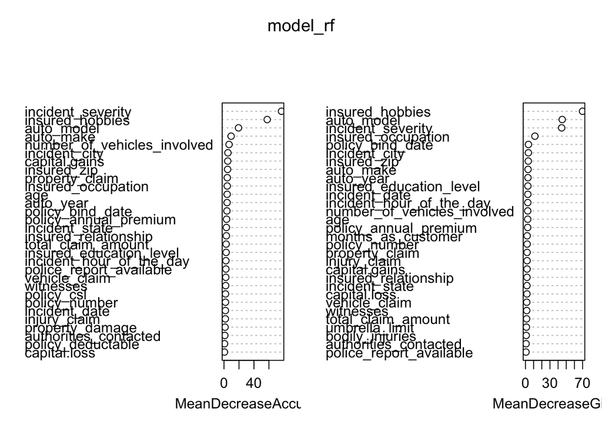

```r
varImpPlot(model_rf)
```

## 4.Neural Network Model In the neural network model, maximum 500 of iterations that gives lowest error rate on both train and test data as shown in the below figure is used while the number of units in the hidden layer is 6.

```r
library(nnet)
```

```r
#Calculate the error and find a best model
err11=0
err12=0
n_tr=dim(TrainSet)[1]
n_te=dim(TestSet)[1]
```

```r
set.seed(123)
for(i in seq(1, 601, 100))
{
  model=nnet(fraud_reported ~ ., data=TrainSet,maxit=i,size=6,decay = 0.1)
  err11[i]=sum(predict(model,TrainSet,type='class')!=TrainSet[,38])/n_tr
  err12[i]=sum(predict(model,TestSet,type='class')!=TestSet[,38])/n_te
}
```

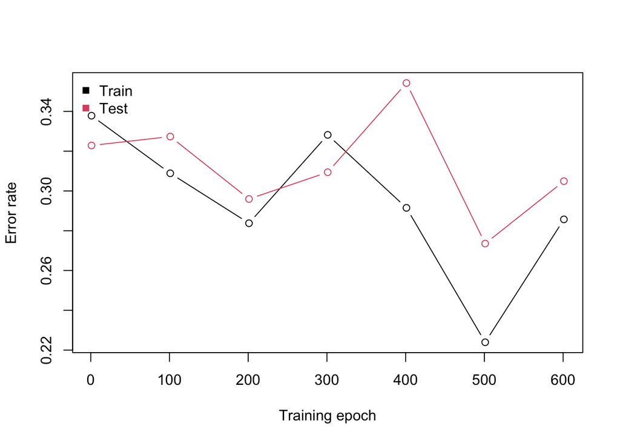

```r
error_1 = na.omit(err11)
error_2 = na.omit(err12)
plot(seq(1, 601, 100),error_1,col=1,type="b",ylab="Error rate",xlab="Training epoch",ylim=c(min(min(error_1),min(error_2)),max(max(error_1),max(error_2))))
lines(seq(1, 601, 100),error_2,col=2,type="b")
legend("topleft",pch=c(15,15),legend=c("Train","Test"),col=c(1,2),bty="n")
```

```r
#Final model and evaluation result
set.seed(123)
model_best=nnet(fraud_reported ~ ., data=TrainSet,maxit=500,size=6,decay = 0.1)
```

```r
#Training Data Confusion Matrix
prediction_train = predict(model_best,TrainSet,type="class")
table_train = table(TrainSet$fraud_reported,prediction_train)
confusionMatrix(table_train, positive = 'Y',mode = "prec_recall")
```

```
## Confusion Matrix and Statistics
##
##    prediction_train
##       N   Y
##   N 138  37
##   Y   2 341
##
##                Accuracy : 0.9247
##                  95% CI : (0.8985, 0.9459)
##     No Information Rate : 0.7297
##     P-Value [Acc > NIR] : < 2.2e-16
##
##                   Kappa : 0.8231
##
##  Mcnemar's Test P-Value : 5.199e-08
##
##               Precision : 0.9942
##                  Recall : 0.9021
##                      F1 : 0.9459
##              Prevalence : 0.7297
##          Detection Rate : 0.6583
##    Detection Prevalence : 0.6622
##       Balanced Accuracy : 0.9439
##
##        'Positive' Class : Y
##
```

The below output shows the testing data confusion matrix and its performance metrics. For 72 total non-fraud data, 31 of them are correctly classified while 41 of them are misclassified. For 151 total fraud data, 130 of them are correctly classified while 21 of them are misclassified. The performance metrics from the confusion matrix are accuracy = 0.722 ; Precision = 0.8609; Recall = 0.7602 ; F1 score = 0.8075.

```r
#Testing Data Confusion Matrix
prediction_test = predict(model_best,TestSet,type="class")
table_test = table(TestSet$fraud_reported,prediction_test)
confusionMatrix(table_test, positive = 'Y',mode = "prec_recall")
```

```
## Confusion Matrix and Statistics
##
##    prediction_test
##       N   Y
##   N  31  41
##   Y  21 130
##
##                Accuracy : 0.722
##                  95% CI : (0.6582, 0.7797)
##     No Information Rate : 0.7668
##     P-Value [Acc > NIR] : 0.94957
##
##                   Kappa : 0.3143
##
##  Mcnemar's Test P-Value : 0.01582
##
##               Precision : 0.8609
##                  Recall : 0.7602
##                      F1 : 0.8075
##              Prevalence : 0.7668
##          Detection Rate : 0.5830
##    Detection Prevalence : 0.6771
##       Balanced Accuracy : 0.6782
##
##        'Positive' Class : Y
##
```

From the performance metrics of training data and testing data, it is found that the values of all metrics of training data are much greater than that of testing data, which indicate the performance of results of training data is better than that of training data and the problem of overfitting occur since the model learn so well with the training data.

## 5.Conclusion

Random forest model is often compared with neural network model as both can model data with non-linear relationships variables and deal with the interactions between them. Considering the performance of both fraud detection models developed, Random Forest Model is more suitable for this case than Neural Network Model.

Firstly, the performances of random forest model on unseen data are better than that of neural network model. Based on the performances on testing data of both models, all performance metrics of random forest model are greater than that of neural network model. Moreover, there is no overfitting problem for the random forest model while there is overfitting problem for the neural network model. The performance on training data is much greater than that on testing data for neural network model, and which means the model completely fits the training data but fails to generalize the testing unseen data. Therefore, random forest model is more suitable in this case.

The interpretability of random forest model is much higher than neural network model. Since neural network is known as ‘black-box’ approach, the model itself delivers results without explanation of how they were derived, and the relationship of inputs and outputs are mathematically complex and opaque. For random forest model, although it consists of an ensemble of individual decision trees which makes it unclear to know the rules from a particular decision tree, we can use the variable importance to understand the internal workings of the model. With the variable importance method, we can understand which attributes more important in the predictions of random forest model. This information is useful in fraud analytics, for auto insurance claims analytics in this case, it is important to gain insights from the fraud detection model to prevent fraud case in the future. For example, from variable importance result of the random forest model, the ‘incidient_severity’ attribute is important in the predictions, and 67% of the fraud case with ‘incidient_severity = Major Damage’, therefore researcher can look further in this attribute for future fraud detection, they can set the conditions for the insurance claims system, if the conditions are meet then the system might give red flag or alerts to the company, so that insurers can hold the case from their customers for the moment and perform further investigations on the claim. And with these interpretabilities from the fraud detection model, the company can also explain and justify their decisions to their customer.

The training process of random process are much simpler, and less training time are required than the training of neural network. For auto insurance dataset, like this dataset, there are often only tabular data, with the use of random forest model, the training process is much simpler than neural network. Also, parameter tuning is not an easy task for neural network model, there is no specific rule for determining the hyperparameters in the neural network (e.g. number of neutrons in each layer), an appropriate model with good results need to be achieved through trial and error and experiences for different combinations of hyperparameters. Moreover, it takes time to find a better neural network model, in this case, the checking with error rate versus the training epoch is performed to find the best number of iterations that comes with smallest error via the iterative optimization, times are needed to go through iterations and the corresponding calculations. And training time for random forest model in this case is faster and less computationally intensive than neural network. For example, for larger insurance company will have larger auto claims insurance dataset. To deal with larger size of dataset, the training process of neural network model will be much longer, and the hardware dependence is also a problem to deal with the computational power required from the model.

Therefore, it is concluded that the Random Forest Model is more suitable for this case than neural network model.